# GALMj

version 1.0

GAMLj version 1.0 is out, a more powerful version, but still neat and easy as the previous ones. Module GAMLj is a suite for [jamovi](https://www.jamovi.org/download.html) to estimate, manipulate, and visualize linear models, from simple regression/ANOVA models (GLM) to mixed models and generalized models (logistic, multinomial and similar linear models). Version 1.0 offers many new features available for all these models, such as conditioning continuous moderators at any value you want ([cf. example](https://mcfanda.github.io/gamlj_docs/glm_example1.html)), improved information about [contrast coding](https://mcfanda.github.io/gamlj_docs/rosetta_contrasts.html) for catagorical variables, and estimation of marginal means at both categorial and continuos variables levels.

Specific new features were also added for each model, like significance testing and plotting of random effects in the [mixed model](https://mcfanda.github.io/gamlj_docs/mixed.html), or normality tests for the [GLM](https://mcfanda.github.io/gamlj_docs/glm.html#assumptions_checks). There’s plenty to explore in GAMLj, and plenty to do.

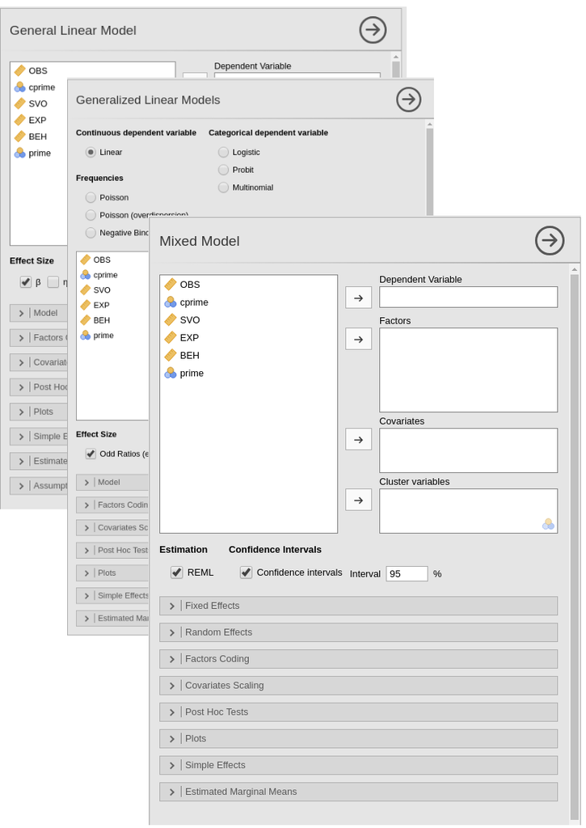

Version 1.0 benefits from several months of testing of previous versions, yielding a module based on more solid code and a robust interface. And the philosophy behind GAMLj is did not change: Providing the user with a simple interface for all the linear models handled by the module, allowing the user to interact in the same way with different models, no matter how complex the models are, or what statistical machinery is working behind the scene.

Users of statistical software, expecially at the beginning of their statistical journey, become familiar with the charateristics of linear models by studying simple regression and ANOVA: in GAMLj, if you know how to run a regression/ANOVA, you can run all the other linear models, flying over the technicality and getting the job done, correctly.

GAMLj offers plenty of tools to explore and test model results. Among the most important, we can highlight:

- Continuous and categorical independent variables
- Omnibus tests and parameter estimates
- Confidence intervals
- Simple slopes analysis
- Simple effects
- Post-hoc tests
- Plots for up to three-way interactions for both categorical and continuous independent variables
- Automatic selection of best estimation methods and degrees of freedom
- Type III estimation
- Estimation of the model in R and manipulation of results and plots with R syntax

All these operations can be done on a plethora of linear models, such as:

- OLS Regression (GLM)
- OLS ANOVA (GLM)
- OLS ANCOVA (GLM)
- Random coefficients regression (Mixed)
- Random coefficients ANOVA-ANCOVA (Mixed)
- Logistic regression (GZLM)
- Logistic ANOVA-like model (GZLM)
- Probit regression (GZLM)
- Probit ANOVA-like model (GZLM)
- Multinomial regression (GZLM)
- Multinomial ANOVA-like model (GZLM)
- Poisson regression (GZLM)
- Poisson ANOVA-like model (GZLM)
- Overdispersed Poisson regression (GZLM)
- Overdispersed Poisson ANOVA-like model (GZLM)
- Negative binomial regression (GZLM)
- Negative binomial ANOVA-like model (GZLM)

## Update

Updating GAMLj to version 1.0 is as simple as for any other module in jamovi. Within jamovi, open the module library and look for GAMLj. Click `update` and you are ready to go.

[figure not shown]

You find the module menus below the `linear models` icon. If you need directions or just want to read more details, help files and examples are available on [GAMLj docs page](https://mcfanda.github.io/gamlj_docs/).